# NOLH Problem Set

Your Name Here

# 1 Introduction

This problem set corresponds to the chapter on advanced designs in the course https://doe.dscoe.org. The solutions for this problem set use the following packages; however, you may use whatever packages you prefer.

```r
library(tidyverse)
library(GGally)
library(readr)
#library(readxl)
#library(scales)
#library(faraway)
```

# 2 NOLH Design

[Download](https://nps.edu/web/seed/software-downloads) the Excel file to create Cioppa’s nearly orthogonal Latin hypercube (NOLH) designs and read the readme tab. Then, create a 17-point design for the following factors and ranges of values (note the decimal places):

- speed: 20.0 to 50.0 KPH
- range: 200 to 300 km
- weight: 45.00 to 50.00 tons

Save your design, read the file into a dataframe, and display the dataframe.

```r
# create a dataframe with factor codings
baseDesign = readxl::read_xls('/cloud/project/html/_Chapter10_ProblemSets/NOLHdesigns_v6.xls',
                        sheet='coded OLH for 7 or fewer',
                        range = "B5:H21",
                        col_names = c('f4', 'f5',   'f7',   'f2',   'f3',   'f6',   'f1'))

designMat = baseDesign %>%
  mutate(
  speed = round(scales::rescale(f4, to=c(20, 50)), 1),
  range = round(scales::rescale(f5, to=c(200, 300)), 0),
  weight = round(scales::rescale(f7, to=c(45, 50)), 2)
  ) %>%
  select(speed, range, weight)

DT::datatable(designMat, options = list(pageLength = 17))
```

|  | speed | range | weight |
| --- | --- | --- | --- |
| 1 | 29.4 | 300 | 49.06 |
| 2 | 21.9 | 225 | 49.38 |
| 3 | 23.8 | 244 | 45.31 |
| 4 | 25.6 | 262 | 46.56 |
| 5 | 42.5 | 294 | 47.19 |
| 6 | 50 | 231 | 46.88 |
| 7 | 38.8 | 219 | 50 |
| 8 | 36.9 | 288 | 48.75 |
| 9 | 35 | 250 | 47.5 |
| 10 | 40.6 | 200 | 45.94 |

[output cut: 7 more lines]

## 2.1 Pairs Plot

Produce a pairs plot.

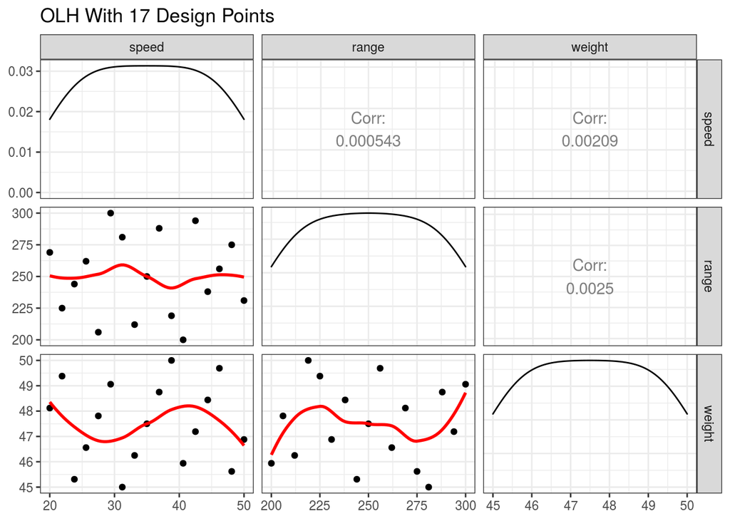

```r
smooth_fn <- function(data, mapping, ...){
  ggplot(data = data, mapping = mapping) +
    geom_point() +
    geom_smooth(formula = y~x, method=loess, fill="red", color="red", se=FALSE, ...)
}

ggpairs(designMat, lower=list(continuous=smooth_fn), progress=FALSE) +
  ggtitle("OLH With 17 Design Points") +
  theme_bw()
```

## 2.2 Integers

Treat the weight factor as an integer and re-generate and re-plot the design. What did you notice?

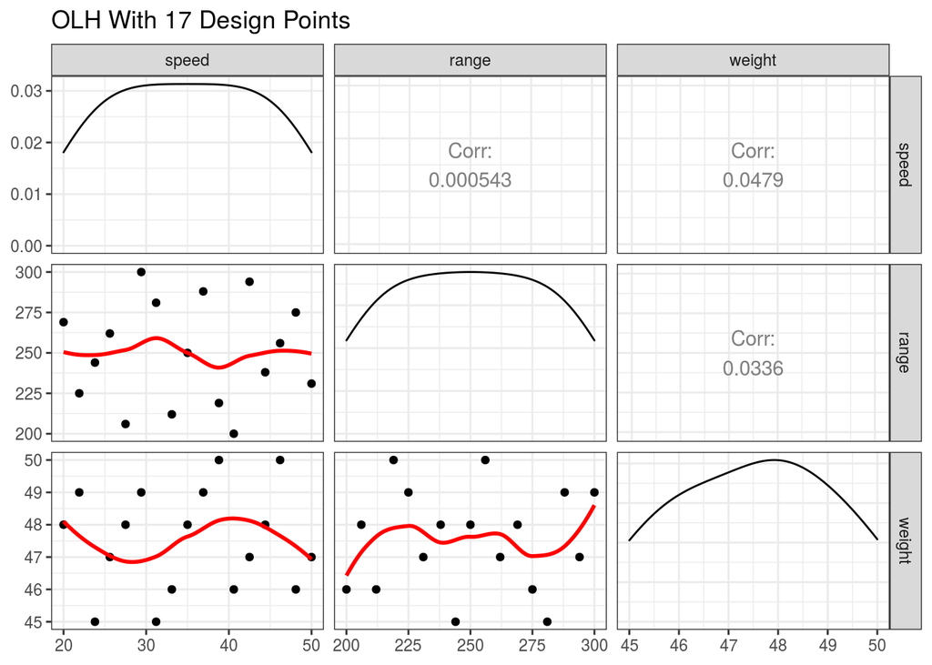

```r
designMat2 = baseDesign %>%
  mutate(
    speed = round(scales::rescale(f4, to=c(20, 50)), 1),
    range = round(scales::rescale(f5, to=c(200, 300)), 0),
    weight = round(scales::rescale(f7, to=c(45, 50)), 0)
  ) %>%
  select(speed, range, weight)

ggpairs(designMat2, lower=list(continuous=smooth_fn), progress=FALSE) +
  ggtitle("OLH With 17 Design Points") +
  theme_bw()
```

```r
# correlations increased, and the patterns shifted, which somewhat compromises the design
```

## 2.3 Factor Codings

On the third tab, `OLH for up to 7 factors`, look at the formula in one of the yellow cells. The formula is pointing to factor codings on a hidden sheet. Right-click on the third tab and unhide the `coded OLH for 7 or fewer` tab. Read the information in the text box to see how the coding works and how the columns are chosen based on the number of factors in your design. Ingest these codings any way you can (you can just type them in an *R* session, but it would be best to use *R* to read the file to reduce the chance of typos). Then, refer to the formula in the yellow cells on the third tab, and re-create your design based on the factor codings and the formula.

```r
# See previous code
```